# **House Prices**

### CUNY SPS DATA 621

#### GROUP 2: William Aiken, Donald Butler, Michael Ippolito, Bharani Nittala, and Leticia Salazar

$~$

$~$

## Key words

house prices, linear models, regression, home investment, real estate

$~$

## Introduction:

The housing market pricing changes can be affected by factors such as mortgage rates, inflation, or economic recessions, to name a few. From 1950 to the present, we witness home price fluctuations, with some steady rising periods between 1950s to the late 1980s. According to the article from Better.com (Johnson, 2022), if we start analyzing the median home value we note that house price growth has risen 326.1% since 1950 with a current median home price of $336,900 (inflation-adjusted to 2020 dollars). There was a 90% drop in production of new homes before the Great Depression started, and, in 1956, President Dwight D. Eisenhower passed the Federal Aid Highway Act that enabled the possibility to access a suburban way of life. By 1960, the boom of home ownership caused home prices started to increase. The Federal Housing Administration (FHA) created changes that allowed Americans to afford homes after WWII which contributed to the rise of home ownership and prices. With a median home price increase of 42.8% by the 1970s, the US economy saw inflation rising and, with it, the housing market. Fast forward to the 1980s, when there were high unemployment rates that caused mortgage interest rates to rise even more. During this time, the median home price (inflation-adjusted to 2020 dollars) had an average interest rate for a 30-year fixed mortgage of 13.7%. By the 1990s, the recession had ended and the housing bubble burst affected only major cities like New York, Boston, Los Angeles, San Diego, Washington D.C., and San Francisco. Entering the 21st century, the average interest rate for a 30-year fixed mortgage was down to 8.1%, as another recession was not expected. By 2008, the US faced challenges that pushed more than 10 million Americans to lose their homes and 9 million to lose their jobs. In 2020, the average interest rate for a 30-year fixed mortgage was 3.1%, with a record-setting year for housing prices. Now we can’t forget the pandemic of COVID-19 that left many to work from home. How does this contribute to the housing prices? Due to the pandemic, housing prices rose once again only to drop in some cities where the demand for homes wasn’t as high. It is believed that housing prices will soon level off and slow down but that mortgage rate will continue to rise.

$~$

## Literature Review

While our assessment didn’t focus on real estate prices on a longitudinal scale, we evaluated the factors that contribute to prices at a single instant in time. Using various predictors, we built a multivariate linear model to predict housing prices based on a dataset we obtained from Kaggle.com (H., 2022). This approach is not new. Multivariate linear modeling to predict housing prices was done previously by Manjula (2017), Man (2017), and others. Our review of current predictive methodologies indicates a number of other approaches have been taken, including machine-learning (Cuturi & Etchebarne, 2021) and sequential models (Majumder, 2022). We limited our approach to constructing a multivariate linear model from a single dataset using a lean set of predictors.

$~$

## Methodology

- Normality of residuals
- Homoschedasticity of residuals
- Independence of predictors
- Linearity of fit

To evaluate normality of residuals, we used the Shapiro test for normality. We used the Breusch-Pagan test to evalute homoschedasticity of residuals. In addition, we examined colinearity problems by looking at variance inflation factors (VIFs). We also evaluated outliers by looking at hat values and comparing them to the a cutoff point based on 2 * (p + 1) / n, where p is the number of parameters and n is the number of observations

Based on our initial modeling attempts, there were no problems with linearity of fit or colinearity among the predictors. However, it was evident that the residuals were heteroschedastic and not normally distributed. We attempted to correct for these problems by applying a log transformation to the response variable (price). While this did yield homoschedastic residuals, they remained non-normally distributed. To attempt to correct for this, we attempted a Huber-weighted robust model. While this didn’t fully correct the issue, we note that in larger datasets, non-normality of residuals doesn’t significant affect model results (Schmidt, 2018), particularly those in which the number of records exceeds ten times the number of predictors. We also examined outliers to evaluate whether there was any trend evident in the data. However, we could discern none, and, therefore, we removed the most significant outliers to attempt a better fit.

$~$

## Experimentation and Resultsm

Once we started our data exploration process we found the following:

- The data is composed of 545 observations and 13 variables (Table 1)
- There were no missing values
- We had to split the data into 70-30 ratio to be able to have a training and evaluation data sets.
- This dataset contains homes with prices above 1 million.

We looked into each variable individually and found the following:

- Based on the distribution of the number of bedrooms, it may be best to categorize these with dummy variables; 2, 3, and 4+.
- Based on the distribution of the number of bathrooms, it may be best to categorize these with dummy variables; 2, and 3+.
- Based on the distribution of stories, it would seem to make sense to classify homes with 3 or more floors together by introducing dummy variables; 2, and 3+.
- It would initially seem to make sense to introduce dummy variables; 1, and 2+.
- The furnishing status variable is taking on three values; unfurnished, semi-furnished, and furnished. Since we would consider unfurnished as the default state, we will use dummy variables; semi-furnished and furnished.
- The main road variable is yes/no based on the street of the home. We will replace this with a dummy variable.
- The guest room variable is yes/no based on the home having a guest room. It is unclear from the dataset source if this is in addition to the number of bedrooms, but we would expect houses with a guest room to have a higher price. We will replace this with a dummy variable.
- The basement variable is yes/no based on the home having a basement. It is unclear if having a basement or not would lead to an increase in home price, but we will replace this with a dummy variable for analysis.
- Based on the distribution, we assume that the hot water heating variable represents if the house has in-floor heating, rather than forced air. Based on this assumption, we assume that having this feature would lead to higher house price. The variable will be replaced with a dummy variable for analysis.
- The air conditioning variable indicates if the house has central air conditioning. We would expect homes with air conditioning would have a higher price than those without. The variable will be replaced with a dummy variable.
- The dataset source doesn’t specify exactly what the “prefarea” variable represents. We are assuming that this is a yes/no value indicating whether the house is in a preferred neighborhood. We would expect houses with a yes to be higher price than those not.

$~$

Once we were ready to start with the data preparation process and knowing there were no missing variables, we introduced a cleaning function to replace our categorical variables with the dummy values. This also ensured that our test and train datasets are processed in the same way. Plots of the cleaned training set were prepared to visually evaluate the data.

$~$

The model-building process started with three models created.

- Model 1 `lm_mod1` was run against the whole data set and yielded an Adjusted R-squared of 0.6755
- Model 2 `lm_mod2` used stepAIC and generated an Adjusted R-squared of 0.6767
- Model 3 `lm_mod3` was created to reduce colinearity and remove low values and yielded an Adjusted R-squared of 0.6703

We developed a function to validate the underlying assumptions of the linear model and evaluated each model against the function. We concluded that residuals were neither normally distributed nor homoschedastic, presenting a problem with the underlying assumptions (Figures 7 and 8). This is confirmed quantitatively using the Shapiro test for normality, which yielded a p-value of 1.33x$10^{11}$. We used the Breusch-Pagan test for homoschedasticity which also yielded a low p-value (9.25x$10^8$), confirming that the residuals are heteroschedastic.

Because of these issues, we chose to run a Box-Cox transformation to give us an idea of whether a transformation of the response variable would be appropriate. The Box-Cox transform resulted in a value of 0.082 on the price variable, indicating that a log transformation would be appropriate. A new model was run and step-reduced, transforming price to use a log scale. While the Shapiro test for normality yielded a higher p-value (0.0274), it still indicated that the residuals were not normally distributed. However, the Breusch-Pagan test resulted in a p-value of 0.221, indicating that the residuals were homoschedastic, a key validation factor. Further, the highest VIF was 2.04, indicating only slight colinearity among some variables. Figure 9 shows the residual analysis visually.

- area
- mainroad
- guestroom
- basement
- bed3
- bed4
- bath2
- floor2
- floor3
- floor4plus
- car1
- car2
- semifurnished
- furnished
- ac
- neighborhood

Using the final model parameters, we generated the predicted prices in the training data and graphed the data against the actual price (Figure 14). This shows a visually good fit. We then repeated the procedure against the validation dataset, analyzed the residuals (Figure 15), and generated an adjusted R-squared value of 0.71, confirming that our model performed equally well against the validation set. Figure 16 visually confirmed the fit. Table 3 summarizes the results of our model runs.

$~$

#### Discussion and Conclusions

We found we were somewhat limited by the data set, in that there appeared to be one or more confounding variables that influenced price and that were not present in the data set. Future research could be done to obtain a richer set of data with additional explanatory variables. That could also mitigate the other limitation we encountered: that of non-normally distributed residuals. However, based on our literature review, that limitation may be less important, as our data set was fairly large compared to the number of explanatory variables.

$~$

## References / Bibliography

- H, M. Y. (2022, January 12). Housing prices dataset. Kaggle. Retrieved November 28, 2022, from https://www.kaggle.com/datasets/yasserh/housing-prices-dataset
- Schmidt, A. (2018, June). Linear Regression and the normality assumption. Retrieved December 5, 2022, from https://doi.org/10.1016/j.jclinepi.2017.12.006
- Johnson, N. (2022, May 24). How much home prices have risen since 1950: Better Mortgage. Better Mortgage Resources. Retrieved December 5, 2022, from https://better.com/content/how-much-home-prices-have-risen-since-1950/
- Majumder, P. (2022, January 27). Using Sequential Model to Predict Prices of Real Estate. Retrieved December 5, 2022, from https://www.analyticsvidhya.com/blog/2022/01/using-sequential-model-to-predict-prices-of-real-estate/
- Cuturi, M. & Etchebarne, G. (2021, June 25). Real Estate pricing with Machine Learning & non-traditional data sources. Retrieved December 5, 2022, from https://tryolabs.com/blog/2021/06/25/real-estate-pricing-with-machine-learning--non-traditional-data-sources
- Man, H. (2017, February 17). Prediction Model-Building a house price model. Retrieved December 5, 2022, from https://medium.com/hanman/data-modeling-building-a-house-price-prediction-model-1450f825073b
- Manjula, R. et al. (2017). Real estate value prediction using multivariate regression models. Retrieved December 5, 2022, from file:///C:/Users/micha/Downloads/Real_estate_value_prediction_using_multivariate_re.pdf

$~$

## Appendices:

### Appendix A. Figures:

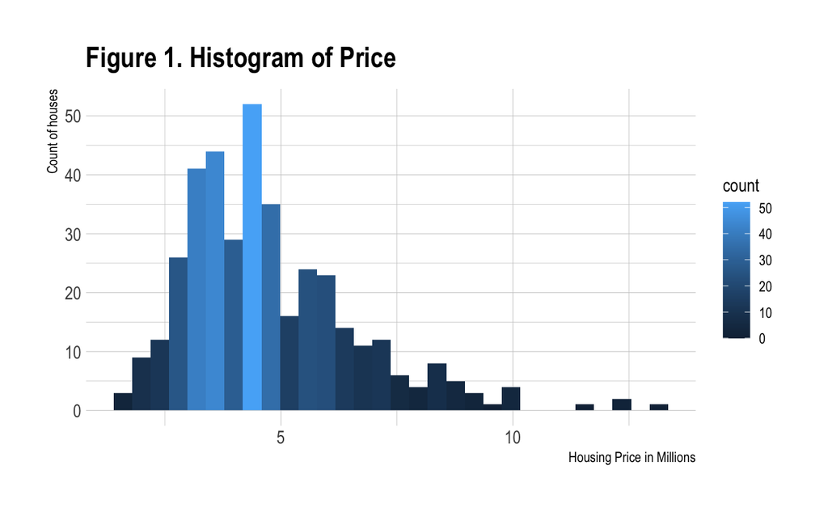

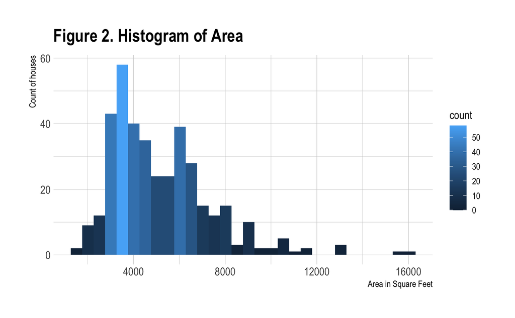

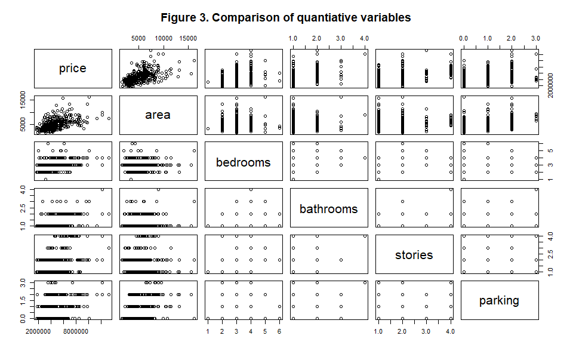

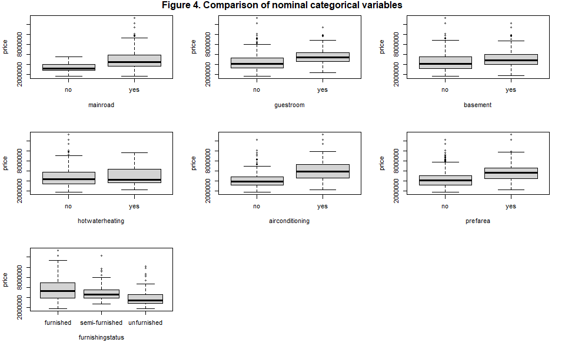

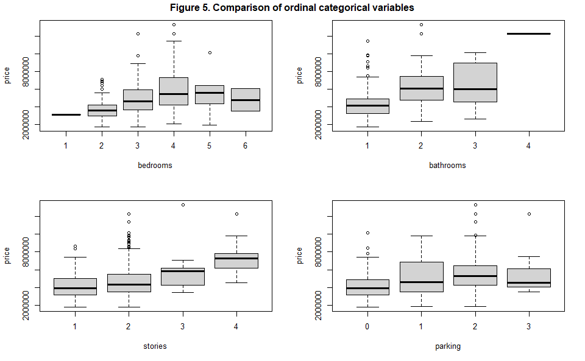

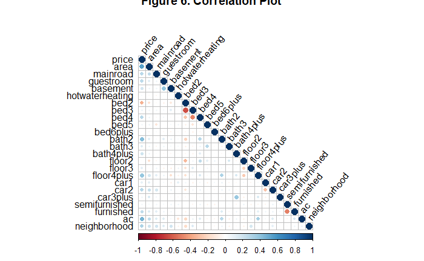

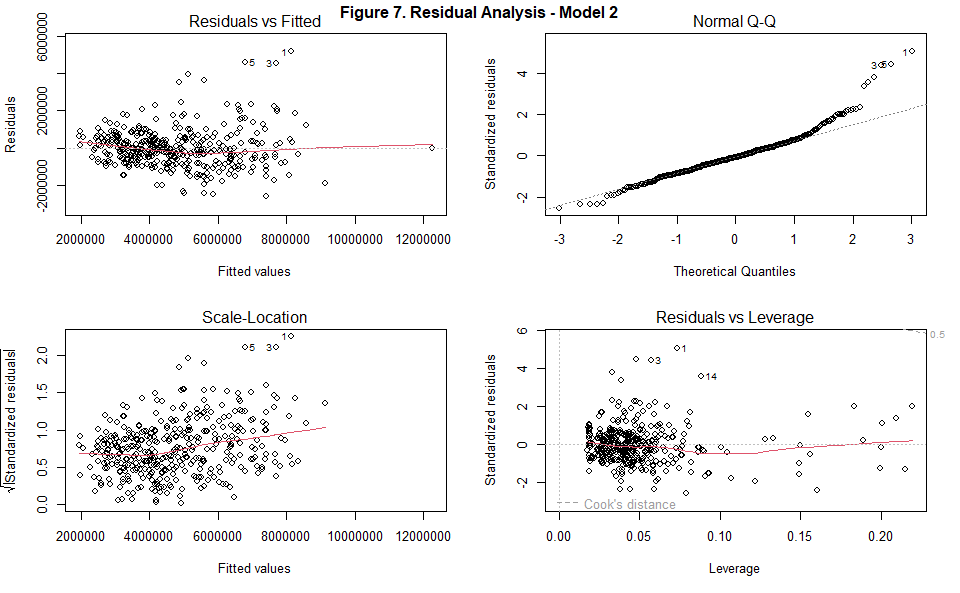

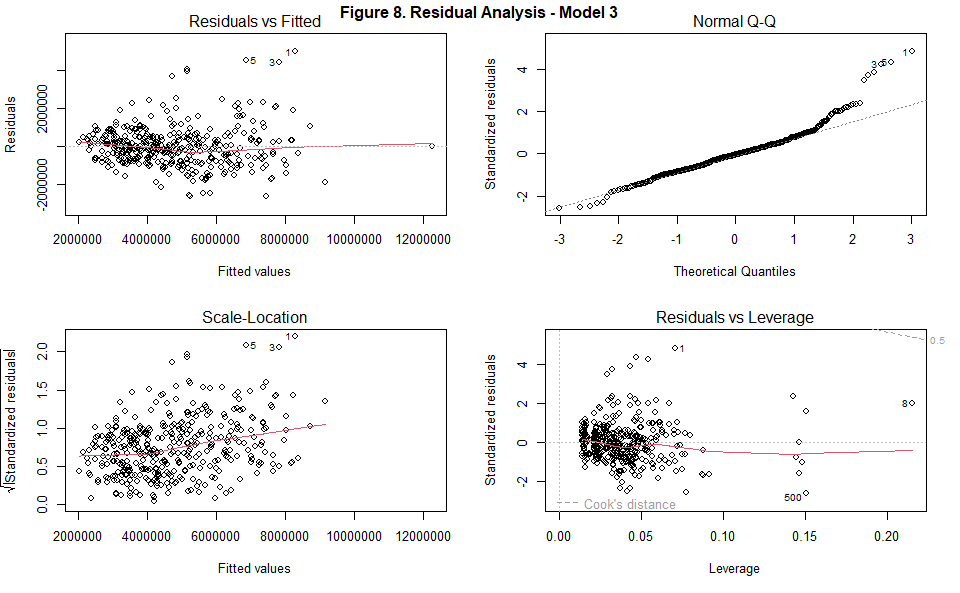

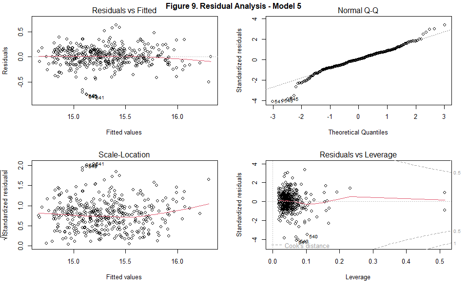

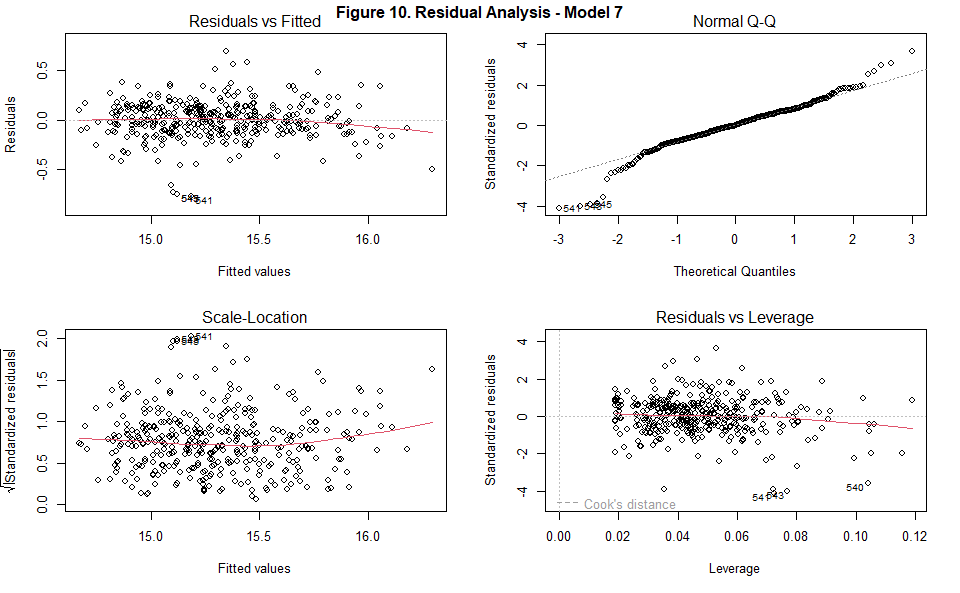

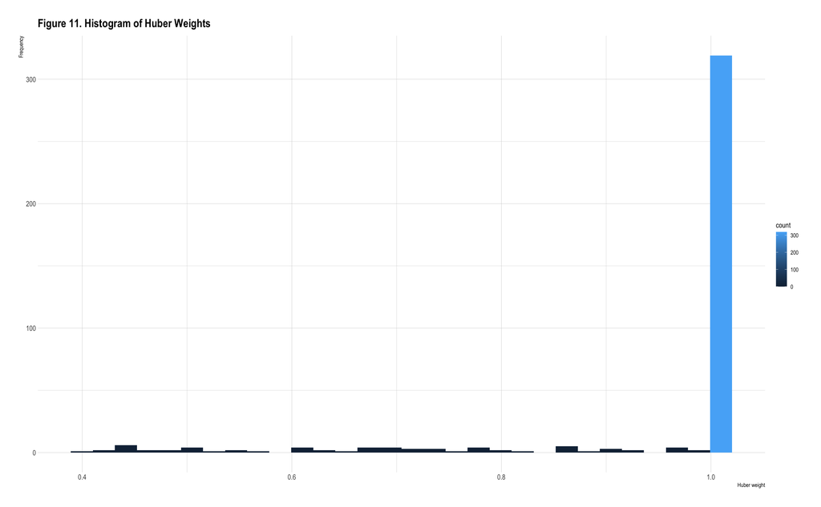

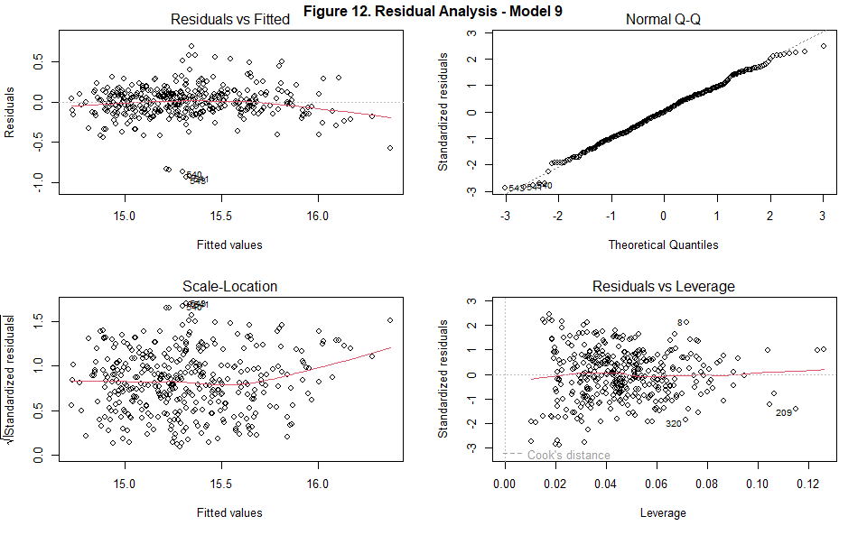

[4 more figures not shown]

$~$

### Appendix B. Tables:

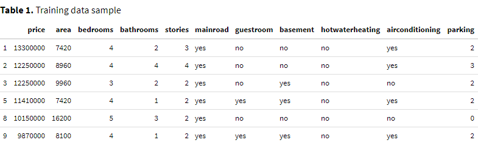

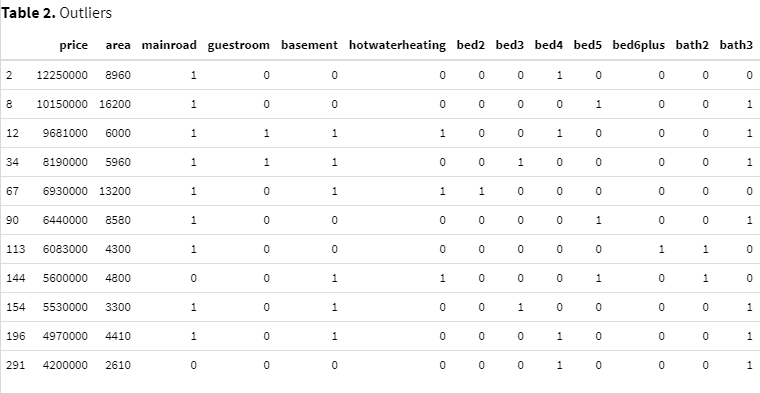

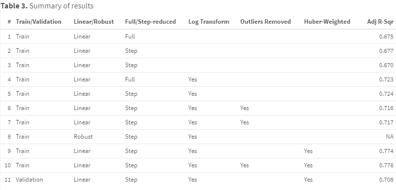

$~$

### Appendix C. R Code:

```r
# load libraries
library(tidyverse)
library(dplyr)
library(corrplot)
library(MASS)
library(dvmisc)
library(car)
library(lmtest)
library(olsrr)
library(caret)
library(kableExtra)
library(hrbrthemes)

# Load data
house_prices <- read.csv("https://raw.githubusercontent.com/letisalba/Data_621/master/Final_Project/csv/Housing.csv")

# make this example reproducible
set.seed(1)

# use 70% of data set as training set and 30% as evaluation set
sample <- sample(c(TRUE, FALSE), nrow(house_prices), replace=TRUE, prob=c(0.7,0.3))
dftrain  <- house_prices[sample, ]
dfeval   <- house_prices[!sample, ]

head(dftrain) %>%
    kable(caption = "<font color=#000000><b>Table 1.</b> Training data sample</font>") %>%
    kable_styling(bootstrap_options = c("hover", "condensed"), font_size = 13)

# data exploration
str(dftrain)

str(dfeval)

summary(dftrain)

summary(dfeval)

# Draw a histogram to figure out the distribution of Sale Price
options(scipen=10000)
ggplot(dftrain, aes(x = price / 10^6, fill = ..count..)) +
  geom_histogram() +
  ggtitle("Figure 1. Histogram of Price") +
  ylab("Count of houses") +
  xlab("Housing Price in Millions") +
  theme(plot.title = element_text(hjust = 0.9)) +
  theme_ipsum()

# Draw a histogram to figure out the distribution of Area
options(scipen=10000)
ggplot(dftrain, aes(x = area, fill = ..count..)) +
  geom_histogram() +
  ggtitle("Figure 2. Histogram of Area") +
  ylab("Count of houses") +
  xlab("Area in Square Feet") +
  theme(plot.title = element_text(hjust = 0.9)) +
  theme_ipsum()

# Counts of categorical variables
dftrain %>% count(bedrooms)
dftrain %>% count(bathrooms)
dftrain %>% count(stories)
dftrain %>% count(parking)
dftrain %>% count(furnishingstatus)
dftrain %>% count(mainroad)
dftrain %>% count(guestroom)
dftrain %>% count(basement)
dftrain %>% count(hotwaterheating)
dftrain %>% count(airconditioning)
dftrain %>% count(prefarea)

# Clean function
fun_clean_df <- function(df) {
  df <- df %>%
    mutate(bed2 = ifelse(bedrooms == 2,1,0)) %>%
    mutate(bed3 = ifelse(bedrooms == 3,1,0)) %>%
    mutate(bed4 = ifelse(bedrooms == 4,1,0)) %>%
    mutate(bed5 = ifelse(bedrooms == 5,1,0)) %>%
    mutate(bed6plus = ifelse(bedrooms >= 6,1,0)) %>% dplyr::select(-bedrooms) %>%
    mutate(bath2 = ifelse(bathrooms == 2,1,0)) %>%
    mutate(bath3 = ifelse(bathrooms == 3,1,0)) %>%
    mutate(bath4plus = ifelse(bathrooms >= 4,1,0)) %>% dplyr::select(-bathrooms) %>%
    mutate(floor2 = ifelse(stories == 2,1,0)) %>%
    mutate(floor3 = ifelse(stories == 3,1,0)) %>%
    mutate(floor4plus = ifelse(stories >= 4,1,0)) %>% dplyr::select(-stories) %>%
    mutate(car1 = ifelse(parking == 1,1,0)) %>%
    mutate(car2 = ifelse(parking == 2,1,0)) %>%
    mutate(car3plus = ifelse(parking >= 3,1,0)) %>% dplyr::select(-parking) %>%
    mutate(semifurnished = ifelse(furnishingstatus == 'semi-furnished',1,0)) %>%
    mutate(furnished = ifelse(furnishingstatus == 'furnished',1,0)) %>% dplyr::select(-furnishingstatus) %>%
    mutate(mainroad = ifelse(mainroad == 'yes',1,0)) %>%
    mutate(guestroom = ifelse(guestroom == 'yes',1,0)) %>%
    mutate(basement = ifelse(basement == 'yes',1,0)) %>%
    mutate(hotwaterheating = ifelse(hotwaterheating == 'yes',1,0)) %>%
    mutate(ac = ifelse(airconditioning == 'yes',1,0)) %>% dplyr::select(-airconditioning) %>%
    mutate(neighborhood = ifelse(prefarea == 'yes',1,0)) %>% dplyr::select(-prefarea)
}

dftrain_clean <- fun_clean_df(dftrain)
dfeval_clean <- fun_clean_df(dfeval)

# Compare quantitative variables
pairs(dftrain[, c('price', 'area', 'bedrooms', 'bathrooms', 'stories', 'parking')], main='Figure 3. Comparison of quantiative variables')
#corrplot(cor(dftrain[, c('price', 'area', 'bedrooms', 'bathrooms', 'stories', 'parking')], use = 'complete.obs'), tl.cex = 0.5)

# Compare nominal categorical variables to price
par(mfrow=c(3, 3))
boxplot(price ~ mainroad, data=dftrain)
boxplot(price ~ guestroom, data=dftrain)
boxplot(price ~ basement, data=dftrain)
boxplot(price ~ hotwaterheating, data=dftrain)
boxplot(price ~ airconditioning, data=dftrain)
boxplot(price ~ prefarea, data=dftrain)
boxplot(price ~ furnishingstatus, data=dftrain)
mtext(expression(bold("Figure 4. Comparison of nominal categorical variables")), side=3, line=-1.5, outer=T)

# Compare ordinal categorical variables
par(mfrow=c(2, 2))
boxplot(price ~ bedrooms, data=dftrain)
boxplot(price ~ bathrooms, data=dftrain)
boxplot(price ~ stories, data=dftrain)
boxplot(price ~ parking, data=dftrain)
mtext(expression(bold("Figure 5. Comparison of ordinal categorical variables")), side=3, line=-1.5, outer=T)

# Correlation plot
cor_res <- cor(dftrain_clean)
corrplot(cor_res,
         type = "lower",
         order = "original",
         tl.col = "black",
         tl.srt = 50,
         tl.cex = 1,
         main = "Figure 6. Correlation Plot")

#partition data
#set.seed(10000)
#train.index <- sample(c(1:dim(dftrain_clean)[1]), dim(dftrain_clean)[1]*0.8)
#model_lin_train = dftrain_clean[train.index,]
#model_lin_valid <- dftrain_clean[-train.index,]
model_lin_train <- dftrain_clean

# Model 1
lm_mod1 <- lm(price ~., data = model_lin_train)
aic_lm_mod1 = AIC(lm_mod1)
summary(lm_mod1)

# Model 2
lm_mod2 <- stepAIC(lm_mod1, trace = F)
aic_lm_mod2 = AIC(lm_mod2)
summary(lm_mod2)

# reduce collinearity, and remove low values
lm_mod3 <- lm(price ~ area + guestroom + basement + bath2 + bath3 +
    bath4plus + floor2 + floor3 + floor4plus + car1 + car2 +
    car3plus + semifurnished + furnished + ac + neighborhood
    - car3plus - bed2,
    data = model_lin_train)
summary(lm_mod3)

# Define function to calculate mean squared error
calc_mse <- function(lmod) {
  return(mean((summary(lmod))$residuals ^ 2))
}

# Define function to aid in model analysis
ModelAnalysis <- function(lmod, plot_title) {

  # Plot residuals
  print('--------------------------------------------------')
  print(lmod$call)
  par(mfrow=c(2,2))
  plot(lmod)
  mtext(bquote(bold(.(plot_title))), side=3, line=-1.5, outer=T)
  print('')

  # Shapiro test to determine normality of residuals
  # Null hypothesis: the residuals are normal.
  # If the p-value is small, reject the null, i.e., consider the residuals *not* normally distributed.
  if (length(lmod$fitted.values) > 3 & length(lmod$fitted.values) < 5000) {
      st <- shapiro.test(lmod$residuals)
      if (st$p.value <= 0.05) {
        print(paste0("Shapiro test for normality: The p-value of ", st$p.value, " is <= 0.05, so reject the null; i.e., the residuals are NOT NORMAL"))
      } else {
        print(paste0("Shapiro test for normality: The p-value of ", st$p.value, " is > 0.05, so do not reject the null; i.e., the residuals are NORMAL"))
      }
      print('')
  } else {
      print("Shapiro test for normality of residuals cannot be performed; sample length must be between 3 and 5000.")
  }
```

```r
  # Breusch-Pagan test to determine homoschedasticity of residuals
  # Null hypothesis: the residuals are homoschedastic.
  # If the p-value is small, reject the null, i.e., consider the residuals heteroschedastic.
  bp <- bptest(lmod)
  if (bp$p.value > 0.05 & bp$statistic < 10) {
      print(paste0("Breusch-Pagan test for homoschedasticity: The p-value of ", bp$p.value, " is > 0.05 and the test statistic of ", bp$statistic,
          " is < 10, so don't reject the null; i.e., the residuals are HOMOSCHEDASTIC."))
  } else if (bp$p.value <= 0.05) {
      print(paste0("Breusch-Pagan test for homoschedasticity: The p-value of ", bp$p.value, " is <= 0.05 and the test statistic is ", bp$statistic,
          ", so reject the null; i.e., the residuals are HETEROSCHEDASTIC."))
  } else {
      print(paste0("Breusch-Pagan test for homoschedasticity: The p-value of ", bp$p.value, " and test statistic of ", bp$statistic,
          " are inconclusive, so homoschedasticity can't be determined using this test. But since the p-value is > 0.05, ",
          "it is reasonable to conclude that the residuals are HOMOSCHEDASTIC."))
  }
  print('')

  # Visually look for colinearity - dont do this for large models
  #pairs(model.matrix(lmod))

  # Variance inflation factor (VIF)
  print('Variance inflation factor (VIF)')
  print('<=1: not correlated, 1-5: moderately correlated, >5: strongly correlated')
  print(sort(vif(lmod), decreasing=T))
  print('')

  # Standardized residual plots (look for points outside of 2 or 3 stdev)
  p <- length(summary(lmod)$coeff[,1] - 1)  # number of model parameters
  stanres <- rstandard(lmod)
  for (i in seq(1, ceiling(p / 4))) {
    par(mfrow=c(2,2))
    starti <- ((i - 1) * 4) + 1
    for (j in seq(starti, starti + 3)) {
      if (j + 1 <= ncol(model.matrix(lmod))) {
        # Skip these plots since we're pretty sure that a linear model isn't valid here
        #plot(model.matrix(lmod)[, j + 1], stanres, xlab=colnames(model.matrix(lmod))[j + 1], ylab='Standardized residuals')
        #abline(h=c(-2, 2), lt=3, col='blue')
        #abline(h=c(-3, 3), lt=2, col='red')
      }
    }
  }

  # Model scores
  print('Model scores:')
  print(paste0('    adjusted R-squared: ', round(summary(lmod)$adj.r.squared, 3)))
  print(paste0('    AIC: ', round(AIC(lmod, k=2), 3)))
  print(paste0('    BIC: ', round(BIC(lmod), 3)))
  print(paste0('    Mallow\'s Cp: ', round(ols_mallows_cp(lmod, fullmodel=lmod), 3)))
  print(paste0('    mean squared error: ', round(calc_mse(lmod), 3)))
  print('')

  # Find leverage point cutoff
  n <- length(lmod$residuals)
  cutoff <- 2 * (p + 1) / n
  print(paste0('Leverage point cutoff: ', cutoff))
  print('')

  # Show points of influence
  print('First 10 points of influence:')
  poi <- lm.influence(lmod)$hat
  len_poi <- length(poi)
  ct <- 0
  for (i in seq(1, length(poi))) {
    if (poi[i] > cutoff) {
      ct <- ct + 1
      print(paste0('    case #', i, ': ', round(poi[i], 3)))
    }
        if (ct > 10) {
            break
        }
  }
  print('')

}

# Analysis on the two step-reduced models
ModelAnalysis(lm_mod2, 'Figure 7. Residual Analysis - Model 2')
ModelAnalysis(lm_mod3, 'Figure 8. Residual Analysis - Model 3')

# Box-Cox transform on price
bc1 <- powerTransform(price ~ ., data=model_lin_train)
bc1

# Box-Cox result suggests doing a log transform on price
lm_mod4 <- lm(log(price) ~ ., data=model_lin_train)
summary(lm_mod4)
lm_mod5 <- stepAIC(lm_mod4, trace=F)
summary(lm_mod5)
ModelAnalysis(lm_mod5, 'Figure 9. Residual Analysis - Model 5')

# Investigate top outliers
model_lin_train[c(2, 5, 9, 25, 49, 62, 77, 103, 110, 136, 210),] %>%
    kable(caption = "<font color=#000000><b>Table 2.</b> Outliers</font>") %>%
    kable_styling(bootstrap_options = c("hover", "condensed"), font_size = 13)

# Log transform on price with outliers removed
lm_mod6 <- lm(formula(lm_mod5),
    data = model_lin_train[c(-2, -5, -9, -25, -49, -62, -77, -103, -110, -136, -210),])
summary(lm_mod6)
lm_mod7 <- stepAIC(lm_mod6, trace=F)
summary(lm_mod7)
ModelAnalysis(lm_mod7, 'Figure 10. Residual Analysis - Model 7')

# Huber robust linear regression
lm_mod8 <- rlm(formula(lm_mod7), data=model_lin_train)
dftmp <- data.frame(cbind(price=model_lin_train$price, huber_weight=lm_mod8$w))
dftmp <- dftmp %>% arrange(huber_weight, ascending=F)
#hist(dftmp$huber_weight, xlab='Huber weight', main='Histogram of Huber Weights')
options(scipen=10000)
ggplot(dftmp, aes(x = huber_weight, fill = ..count..)) +
  geom_histogram() +
  ggtitle("Figure 11. Histogram of Huber Weights") +
  ylab("Frequency") +
  xlab("Huber weight") +
  theme(plot.title = element_text(hjust = 0.9)) +
  theme_ipsum()

# New linear model using Huber weights
lm_mod9 <- lm(formula(lm_mod7), weights=lm_mod8$w, data=model_lin_train)
summary(lm_mod9)
ModelAnalysis(lm_mod9, 'Figure 12. Residual Analysis - Model 9')

# Remove most significant outliers
lm_mod10 <- lm(formula(lm_mod7), weights=lm_mod8$w[c(-53, -68, -87, -90, -103)],
    data=model_lin_train[c(-53, -68, -87, -90, -103),])
summary(lm_mod10)
ModelAnalysis(lm_mod10, 'Figure 13. Residual Analysis - Model 10')

# Five-fold cross validation
set.seed(777)
tc <- trainControl(method = "cv", number = 5)
lmcv <- train(formula(lm_mod8), weights=lm_mod8$w, data=model_lin_train, method="lm", trControl=tc)
print(lmcv)
summary(lmcv)

# Compare predicted price to actual (training data)
model_lin_train$pred_price <- exp(predict(lm_mod10, weights=lm_mod8$w, data=model_lin_train, interval='prediction')[,1])
model_lin_train %>% ggplot(mapping=aes(x=price, y=pred_price)) +
    geom_point() +
    geom_smooth(method='lm', se=T) +
    xlab('Price') + ylab('Predicted Price') +
    ggtitle('Figure 14. Predicted Price vs Price (Training Data)') +
  theme_ipsum()

# Huber robust linear regression
lm_valid1 <- rlm(formula(lm_mod7), data=dfeval_clean)

# New linear model using Huber weights
lm_valid2 <- lm(formula(lm_mod7), weights=lm_valid1$w, data=dfeval_clean)
summary(lm_valid2)
ModelAnalysis(lm_valid2, 'Figure 15. Residual Analysis - Validation Set')
```

```r
# Compare predicted price to actual (eval data)
dfeval_clean$pred_price <- exp(predict(lm_valid2, weights=lm_valid1$w, data=dfeval_clean, interval='prediction')[,1])
dfeval_clean %>% ggplot(mapping=aes(x=price, y=pred_price)) +
    geom_point() +
    geom_smooth(method='lm', se=T) +
    xlab('Price') + ylab('Predicted Price') +
    ggtitle('Figure 16. Predicted Price vs Price (Validation Data)') +
  theme_ipsum()

# Model comparison
hdr <- c('#', 'Train/Validation', 'Linear/Robust', 'Full/Step-reduced', 'Log Transform',
    'Outliers Removed', 'Huber-Weighted', 'Adj R-Sqr')
f1 <- c(seq(1:11))
f2 <- c(rep('Train', 10), 'Validation')
f3 <- c(rep('Linear', 7), 'Robust', rep('Linear', 3))
f4 <- c('Full', 'Step', 'Step', 'Full', rep('Step', 7))
f5 <- c(rep('', 3), rep('Yes', 8))
f6 <- c(rep('', 5), 'Yes', 'Yes', '', '', 'Yes', '')
f7 <- c(rep('', 8), rep('Yes', 3))
f8 <- round(c(
    summary(lm_mod1)$adj.r.squared,
    summary(lm_mod2)$adj.r.squared,
    summary(lm_mod3)$adj.r.squared,
    summary(lm_mod4)$adj.r.squared,
    summary(lm_mod5)$adj.r.squared,
    summary(lm_mod6)$adj.r.squared,
    summary(lm_mod7)$adj.r.squared,
    NA,
    summary(lm_mod9)$adj.r.squared,
    summary(lm_mod10)$adj.r.squared,
    summary(lm_valid2)$adj.r.squared), 3)
dfresult <- data.frame(f1, f2, f3, f4, f5, f6, f7, f8)
colnames(dfresult) <- hdr
dfresult %>%
    kable(caption = "<font color=#000000><b>Table 3.</b> Summary of results</font>") %>%
    kable_styling(bootstrap_options = c("hover", "condensed"), font_size = 13)
```